# Eflow species

Combines the eflow classifications with the PISCES species data. This notbook relies on steps from two other notebooks `eflows-db.Rmd` which pulls data from the PISCES data base and save it as a csv and `eflows-distance.Rmd` which calculates the total stream distance of each eflow class in each HUC12.

## Join the species info to the huc12 percent data

Since we want both extreams for the threashold (0%, 100%) let’s start by joining the species data to the huc12 eflow percent dataframe. The end result will be that every combination of huc12~eflow type will be assigned all the species that were found in the watershed. We know that this is probably not going to be the case and there will be a threshold but this is neccissary since we need to run both extreams (0% and 100% dominance).

```r
# joins all the species info the eflow huc12 %'s
eflows_percents_fish  <- left_join(huc12_eflow_percents, pisces_huc12_list, by=c("HUC12"="HUC_12"))
```

## filter

Set the percentage to use as a threshold. If a eflow class percentage of total river segments is above the threshold than all of the species are assigned to the HUC, otherwise that class is ignored. This is necessiary since many of the HUC12s only contain a small ammount of a given eflow class that may not be representive of the habitat needs of the species records pulled from the database.

```r
# todo this is the spot to filter by percentage
filter_percents <- function(data, threshold){
  data_p <- data %>% filter(percent>=threshold)
  return(data_p)
}
```

## Summarize by HUC6s or HUC12s

```r
# summarize the number of species in each huc6, number of natives, number of non-natives, count of the number of endangered species

summarize_huc6 <- function(data){
  # collect all the unique observations at the huc 6
  # since the original data is at the huc12 scale using distinct
  # will essentially concatonate all the inside data
  unique_huc6 <- data %>%
    distinct(HUC6, eflow_type, eflow_name, abbr, name, species_id,
             common_name, native, ca_status, fed_listing, ca_listing)

  # summary counts using the huc6 scale
  summary_huc6 <- unique_huc6 %>%
    group_by(HUC6, eflow_type, eflow_name) %>%
    dplyr::summarize(count_native=sum(native==1), count_nonnative=sum(native==0),
                     count_fed_threatened=sum(fed_listing=="T"), count_fed_endangered=sum(fed_listing=="E"),
                     count_fed_TE=sum(fed_listing=="E"|fed_listing=="T"), species_list=paste(common_name, collapse = ", "))
  return(summary_huc6)
}


summarize_huc12 <- function(data){
  # collect all the unique observations at the huc 12
  # since the original data is at the huc12 scale using distinct
  # will essentially concatonate all the inside data
  unique_huc <- data %>%
    distinct(HUC12, eflow_type, eflow_name, abbr, name, species_id,
             common_name, native, ca_status, fed_listing, ca_listing)

  # summary counts using the huc6 scale
  summary_huc <- unique_huc %>%
    group_by(HUC12, eflow_type, eflow_name) %>%
    dplyr::summarize(count_native=sum(native==1), count_nonnative=sum(native==0),
                     count_fed_threatened=sum(fed_listing=="T"), count_fed_endangered=sum(fed_listing=="E"),
                     count_fed_TE=sum(fed_listing=="E"|fed_listing=="T"), species_list=paste(common_name, collapse = ", "))
  return(summary_huc)
}
```

## Threshold maps - species counts

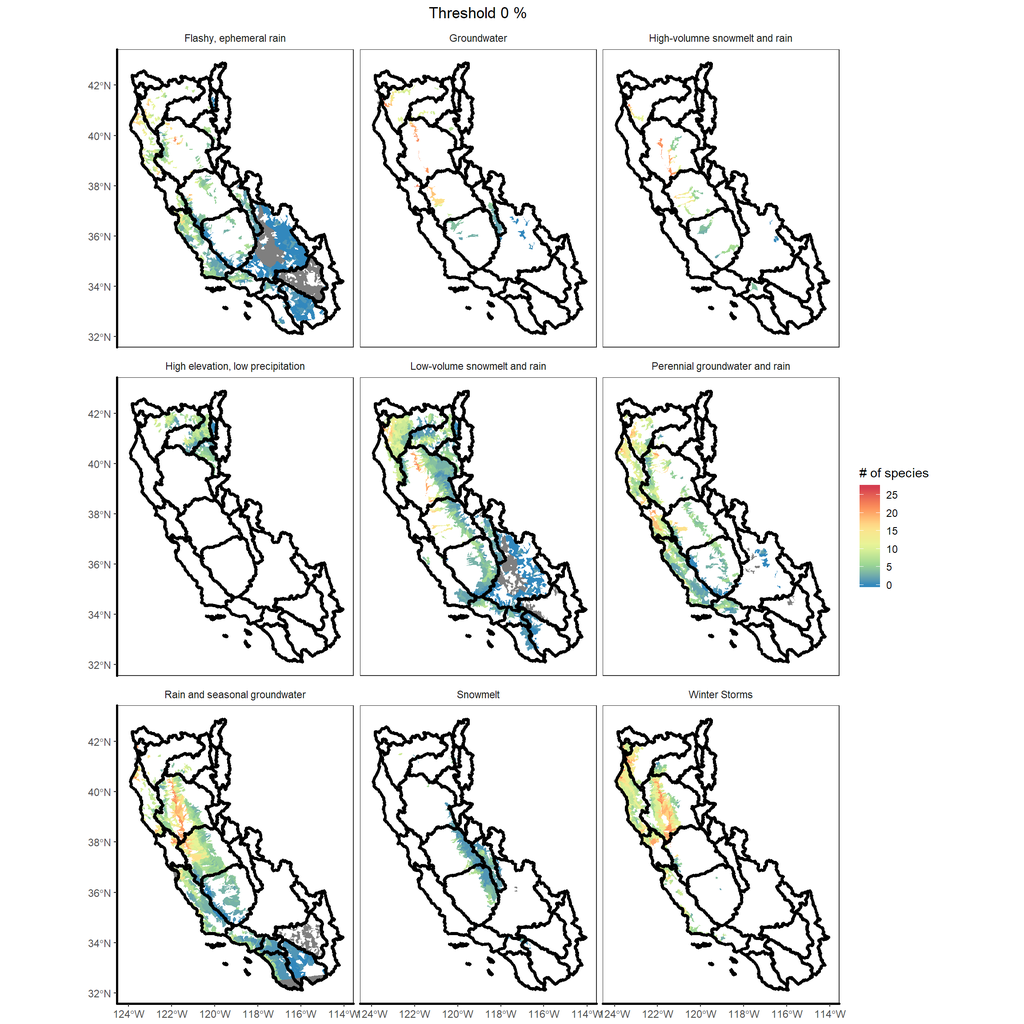

```r
p <- native_species_threshold_map(eflows_percents_fish, 0)
p
```

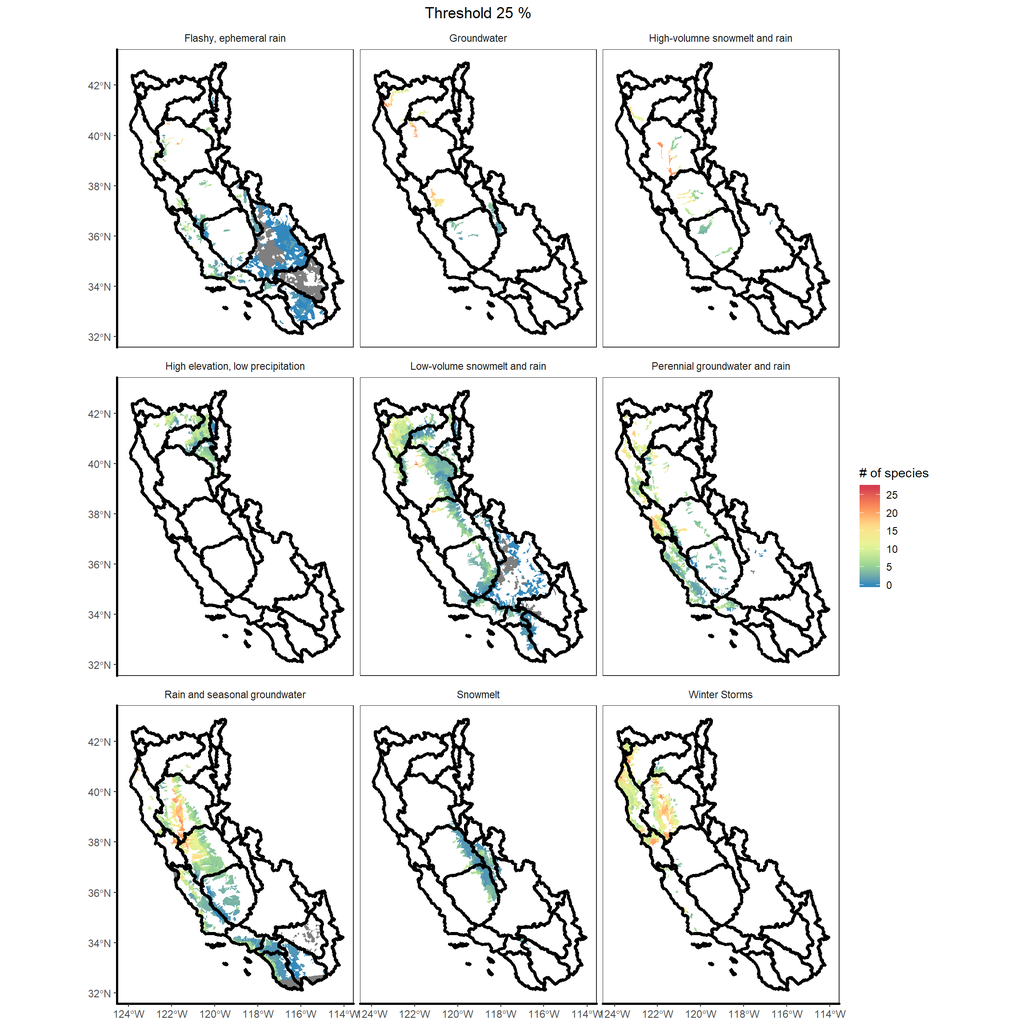

```r
p <- native_species_threshold_map(eflows_percents_fish, 0.25)
p
```

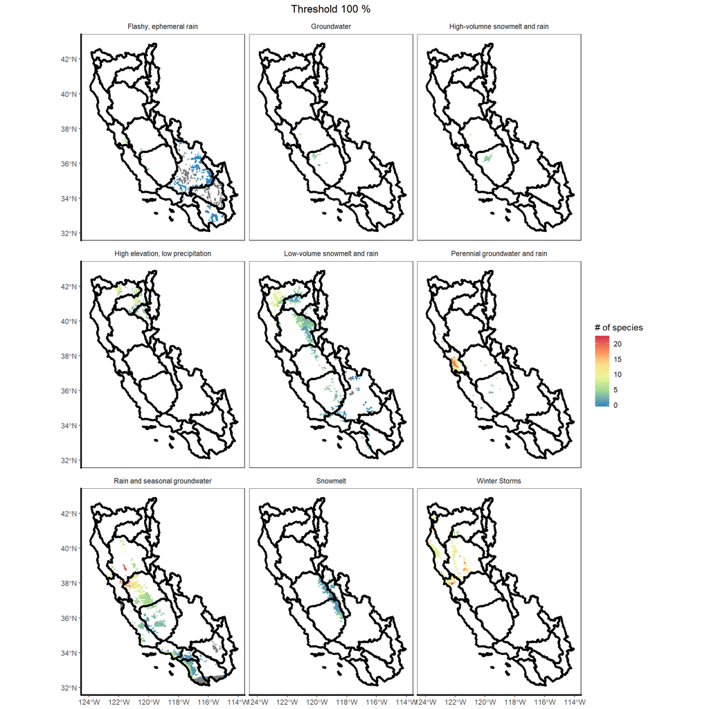

```r
p <- native_species_threshold_map(eflows_percents_fish, 1)
p
```

## Summary csv using 25% threshold with species lost column

```r
huc6_summary_25percent <- summarize_huc6(filter_percents(eflows_percents_fish, 0.25)) %>%
    rowwise() %>%
    mutate(threshold_species_list=strsplit(species_list, split=", "))


# select the rows that are dropped using an anti-join
huc6_summary_0percent <- summarize_huc6(filter_percents(eflows_percents_fish, 0)) %>%
  rowwise() %>%
  mutate(nothreshold_species_list=strsplit(species_list, split=", ")) %>%
  select(c(HUC6, eflow_type, nothreshold_species_list))

# join the two to list the species that are lost using the threshold
join <- left_join(huc6_summary_25percent, huc6_summary_0percent, by=c("HUC6", "eflow_type"))

# find the species that are present in the huc 6 when there is no threshold set
# but get removed when using the threshold. These species will be added to a column
# called threshold_species_lost
huc6_summary_25percent_w_losses <- join %>% rowwise() %>%
  mutate(threshold_species_lost=paste(nothreshold_species_list[(nothreshold_species_list %in% threshold_species_list)==FALSE],  collapse=", ")) %>% select(-c(nothreshold_species_list, threshold_species_list))

huc6_summary_25percent_w_losses
```

| HUC6 | eflow_type | eflow_name | count_native | count_nonnative | count_fed_threatened | count_fed_endangered | count_fed_TE | species_list | threshold_species_lost |
| --- | --- | --- | --- | --- | --- | --- | --- | --- | --- |
| 180101 | FER | Flashy, ephemeral rain | 24 | 14 | 4 | 2 | 6 | Humboldt sucker, Coastal rainbow trout, Sacramento pikeminnow, Southern Oregon Northern California coast coho salmon, Pacific lamprey, Central California roach, Golden shiner, Brown bullhead, Largemou… | Coastal cutthroat trout, Northern green sturgeon, White sturgeon, Eulachon, Longfin smelt, Navarro roach, Pink salmon, Gualala roach, Central California coast winter steelhead, Black bullhead, White c… |
| 180101 | LSR | Low-volume snowmelt and rain | 18 | 11 | 4 | 0 | 4 | Coastrange sculpin, Western brook lamprey, Klamath Mountains Province winter steelhead, Coastal rainbow trout, Southern Oregon Northern California coast fall Chinook salmon, Southern Oregon Northern C… |  |
| 180101 | PGR | Perennial groundwater and rain | 39 | 19 | 6 | 2 | 8 | Coastrange sculpin, Western brook lamprey, Klamath Mountains Province winter steelhead, Coastal rainbow trout, Southern Oregon Northern California coast fall Chinook salmon, Southern Oregon Northern C… | Longfin smelt |
| 180101 | RGW | Rain and seasonal groundwater | 36 | 18 | 6 | 2 | 8 | Coastal rainbow trout, Northern green sturgeon, Staghorn sculpin, Chum salmon, Eulachon, Western brook lamprey, Southern Oregon Northern California coast coho salmon, River lamprey, Coastrange sculpin… | Klamath smallscale sucker, Navarro roach, Pink salmon, Striped bass, Mississippi silversides |
| 180101 | WS | Winter Storms | 41 | 19 | 6 | 2 | 8 | Coastrange sculpin, Western brook lamprey, Klamath Mountains Province winter steelhead, Coastal rainbow trout, Southern Oregon Northern California coast fall Chinook salmon, Southern Oregon Northern C… | Brown Trout |
| 180102 | GW | Groundwater | 28 | 14 | 2 | 1 | 3 | Klamath speckled dace, Klamath Mountains Province winter steelhead, Coastal rainbow trout, Upper Klamath-Trinity fall Chinook salmon, Upper Klamath-Trinity spring Chinook salmon, Lower Klamath marbled… | Shortnose sucker, Upper Klamath marbled sculpin, Blue chub, Klamath largescale sucker, Lost River sucker, Sacramento perch, White crappie, Pumpkinseed, Western mosquitofish, Goldfish, Klamath tui chub… |
| 180102 | HLP | High elevation, low precipitation | 19 | 17 | 1 | 2 | 3 | Shortnose sucker, Blue chub, Klamath speckled dace, Coastal rainbow trout, Golden shiner, Western mosquitofish, Goldfish, Brown bullhead, Largemouth Bass, Bluegill, Green sunfish, Klamath largescale s… | Inland threespine stickleback |
| 180102 | HSR | High-volumne snowmelt and rain | 17 | 9 | 1 | 0 | 1 | Klamath speckled dace, Klamath Mountains Province winter steelhead, Coastal rainbow trout, Upper Klamath-Trinity fall Chinook salmon, Upper Klamath-Trinity spring Chinook salmon, Klamath Mountains Pro… | Eulachon, River lamprey, Southern Oregon Northern California coast fall Chinook salmon, Lower Klamath marbled sculpin, Coastal cutthroat trout, Fathead minnow, Yellow perch |
| 180102 | LSR | Low-volume snowmelt and rain | 27 | 19 | 1 | 2 | 3 | Shortnose sucker, Klamath speckled dace, Coastal rainbow trout, White crappie, Golden shiner, Western mosquitofish, Largemouth Bass, Bluegill, Green sunfish, Lost River sucker, Sacramento perch, Black… | Upper Klamath marbled sculpin, Fathead minnow, Eulachon, River lamprey, Staghorn sculpin, Coastal threespine stickleback, Tidewater goby, Starry flounder, Longfin smelt, Pink salmon, Striped bass |
| 180102 | PGR | Perennial groundwater and rain | 19 | 15 | 1 | 0 | 1 | Klamath speckled dace, Klamath Mountains Province winter steelhead, Coastal rainbow trout, Upper Klamath-Trinity fall Chinook salmon, Upper Klamath-Trinity spring Chinook salmon, Lower Klamath marbled… | River lamprey |

[output cut: 76 more lines]

```r
write.csv(huc6_summary_25percent_w_losses, "HUC6_summary_25percent_threshold.csv", row.names = FALSE)
```